# Eda-1

Raquel Lopes e Nazareno Andrade

6/6/2018

## O que vamos aprender/revisar?

- Escalas de medições;
- Sumarização de dados;
- Distribuição de uma variável com histogramas;
- Relações entre 2 variáveis.

## Escalas de variáveis

Para entender os dados precisamos conhecer suas escalas.

- Escala categórica;
- Escala ordinal;
- Escala intervalar;
- Escala de razão.

```r
setwd("/Users/raquelvl/Documents/raquel/disciplinas/2018.1/MC/aulas/")
alunos.tudo <- read_csv("dados/alunos-ad1.csv")
glimpse(alunos.tudo)
```

```
## Observations: 44
## Variables: 15
## $ `#`                                                                                                 <chr> ...
## $ `Você é...`                                                                                         <chr> ...
## $ `Você já cursou, está cursando ou não cursou Métodos Estatísticos?`                                 <chr> ...
## $ `Em quantos repositórios no github (seus ou de outras pessoas) você contribuiu nos últimos 2 anos?` <int> ...
## $ `Em quantas linguagens de programação você sabe programar?`                                         <int> ...
## $ `Qual seu nível de confiança hoje no que você sabe sobre o que é desvio padrão?`                    <int> ...
## $ `Em quantos projetos de desenvolvimento ou pesquisa você já participou na UFCG?`                    <int> ...
## $ `Qual a sua altura em centímetros?`                                                                 <int> ...
## $ `Qual seu peso aproximado em kg?`                                                                   <int> ...
## $ `Quanto tempo você demora para se deslocar de casa à UFCG? (em minutos)`                            <int> ...
## $ `Você geralmente vai de casa para a UFCG:`                                                          <chr> ...
## $ `O quanto você gosta de formulários online? (Obrigado por ter respondido este!)`                    <int> ...
## $ `Start Date (UTC)`                                                                                  <dttm> ...
## $ `Submit Date (UTC)`                                                                                 <dttm> ...
## $ `Network ID`                                                                                        <chr> ...
```

```r
# interativo, você pode fazer:
```

```r
# você pode especificar os tipos das colunas, por exemplo:
alunos.tudo = read_csv("dados/alunos-ad1.csv",
                       col_types = "ccciiiiiiici??c")
```

```r
alunos.tudo %>% View()
# que é o mesmo que View(alunos)
```

Os nomes de variável vem do dataset e não estão ajudando. Vamos renomeá-las.

```r
names(alunos.tudo)
```

```
##  [1] "#"
##  [2] "Você é..."
##  [3] "Você já cursou, está cursando ou não cursou Métodos Estatísticos?"
##  [4] "Em quantos repositórios no github (seus ou de outras pessoas) você contribuiu nos últimos 2 anos?"
##  [5] "Em quantas linguagens de programação você sabe programar?"
##  [6] "Qual seu nível de confiança hoje no que você sabe sobre o que é desvio padrão?"
##  [7] "Em quantos projetos de desenvolvimento ou pesquisa você já participou na UFCG?"
##  [8] "Qual a sua altura em centímetros?"
##  [9] "Qual seu peso aproximado em kg?"
## [10] "Quanto tempo você demora para se deslocar de casa à UFCG? (em minutos)"
## [11] "Você geralmente vai de casa para a UFCG:"
## [12] "O quanto você gosta de formulários online? (Obrigado por ter respondido este!)"
## [13] "Start Date (UTC)"
## [14] "Submit Date (UTC)"
## [15] "Network ID"
```

```r
alunos = alunos.tudo %>%
  select(sexo = `Você é...`,  # select pode escolher e/ou renomear variáveis
         repositorios = `Em quantos repositórios no github (seus ou de outras pessoas) você contribuiu nos últimos 2 anos?`,
         linguagens = `Em quantas linguagens de programação você sabe programar?`,
         altura = `Qual a sua altura em centímetros?`,
         tempo_para_ufcg = `Quanto tempo você demora para se deslocar de casa à UFCG? (em minutos)`,
         transporte = `Você geralmente vai de casa para a UFCG:`,
         gosta_de_forms = `O quanto você gosta de formulários online? (Obrigado por ter respondido este!)`)

names(alunos)
```

```
## [1] "sexo"            "repositorios"    "linguagens"      "altura"
## [5] "tempo_para_ufcg" "transporte"      "gosta_de_forms"
```

```r
alunos %>% View()

glimpse(alunos)
```

```
## Observations: 44
## Variables: 7
## $ sexo            <chr> "Homem", "Mulher", "Homem", "Homem", "Homem", ...
## $ repositorios    <int> 3, 9, 2, 2, 10, 5, 20, 10, 4, 4, 5, 6, 1, 4, 1...
## $ linguagens      <int> 5, 3, 3, 2, 5, 4, 3, 5, 8, 3, 4, 4, 3, 6, 5, 2...
## $ altura          <int> 0, 154, 0, 181, 186, 182, 184, 167, 182, 160, ...
## $ tempo_para_ufcg <int> 73, 20, 10, 10, 19, 30, 60, 25, 15, 90, 7, 20,...
## $ transporte      <chr> NA, "de carro/moto", "de carro/moto", "a pé", ...
## $ gosta_de_forms  <int> 1, 3, 5, 4, 4, 5, 4, 5, 3, 3, 2, 2, 4, 3, 5, 4...
```

## Observações

O que significa uma observação neste dataset? Isso precisa *sempre* ser entendido.

### Variáveis categóricas

O que são? Existem variáveis categóricas no nosso dataset?

```r
glimpse(alunos)
```

```
## Observations: 44
## Variables: 7
## $ sexo            <chr> "Homem", "Mulher", "Homem", "Homem", "Homem", ...
## $ repositorios    <int> 3, 9, 2, 2, 10, 5, 20, 10, 4, 4, 5, 6, 1, 4, 1...
## $ linguagens      <int> 5, 3, 3, 2, 5, 4, 3, 5, 8, 3, 4, 4, 3, 6, 5, 2...
## $ altura          <int> 0, 154, 0, 181, 186, 182, 184, 167, 182, 160, ...
## $ tempo_para_ufcg <int> 73, 20, 10, 10, 19, 30, 60, 25, 15, 90, 7, 20,...
## $ transporte      <chr> NA, "de carro/moto", "de carro/moto", "a pé", ...
## $ gosta_de_forms  <int> 1, 3, 5, 4, 4, 5, 4, 5, 3, 3, 2, 2, 4, 3, 5, 4...
```

Que tipo de manipulação podemos fazer com variáveis categóricas?

```r
num.homens <- alunos %>% filter(sexo == "Homem") %>% summarise(count(.))
num.mulheres <- alunos %>% filter(sexo == "Mulher") %>% summarise(count(.))

ifelse(num.homens > num.mulheres, "Homem", "Mulher")
```

```
##      count(.)
## [1,] "Homem"
```

```r
num.homens/(num.homens+num.mulheres)
```

```
##           n
## 1 0.8604651
```

Outra forma de ver a moda é como a seguir:

```r
max(table(alunos$sexo))/sum(table(alunos$sexo))
```

```
## [1] 0.8604651
```

Os homens são top-86%. O que significa isso? Vejamos um exemplo com mais categorias: transporte

```r
summary(as.factor(alunos$transporte))
```

```
##          a pé de carro/moto     de ônibus          NA's
##             7            20            16             1
```

```r
alunos %>% filter(!is.na(transporte)) %>%
  group_by(transporte) %>% summarise(n=n())
```

```
## # A tibble: 3 x 2
##   transporte        n
##   <chr>         <int>
## 1 a pé              7
## 2 de carro/moto    20
## 3 de ônibus        16
```

Quem é a moda? E em termos de dispersão, o que podemos dizer?

```r
max(table(alunos$transporte))/sum(table(alunos$transporte))
```

```
## [1] 0.4651163
```

## Gráficos de barra

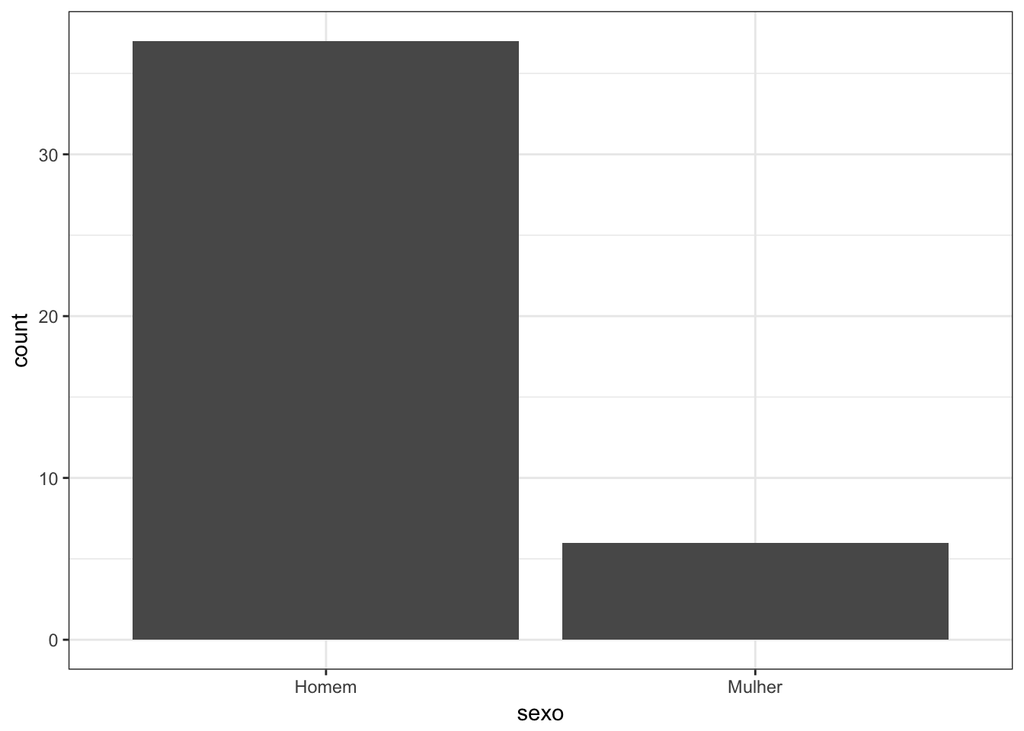

```r
ggplot(alunos %>% filter(!is.na(sexo))) +
  geom_bar(mapping = aes(x = sexo))
```

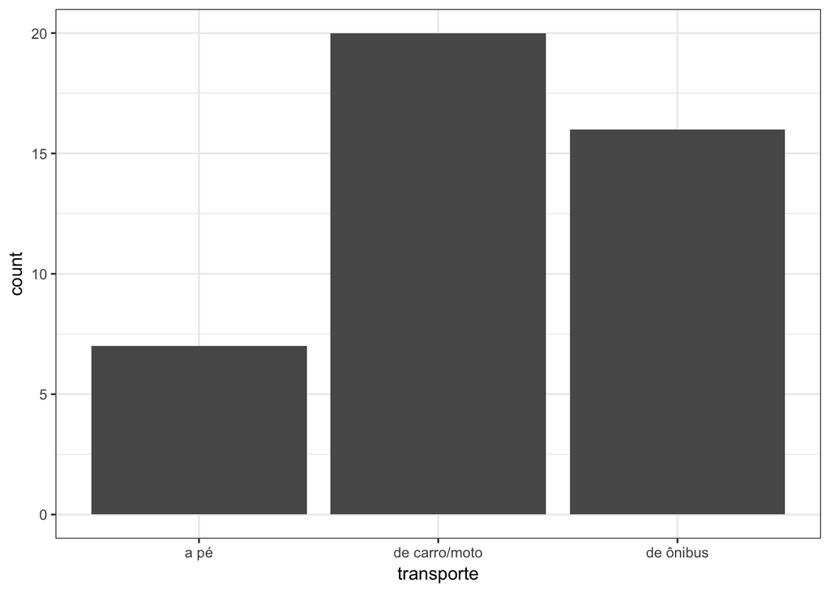

```r
ggplot(alunos %>% filter(!is.na(transporte))) +
  geom_bar(mapping = aes(x = transporte))
```

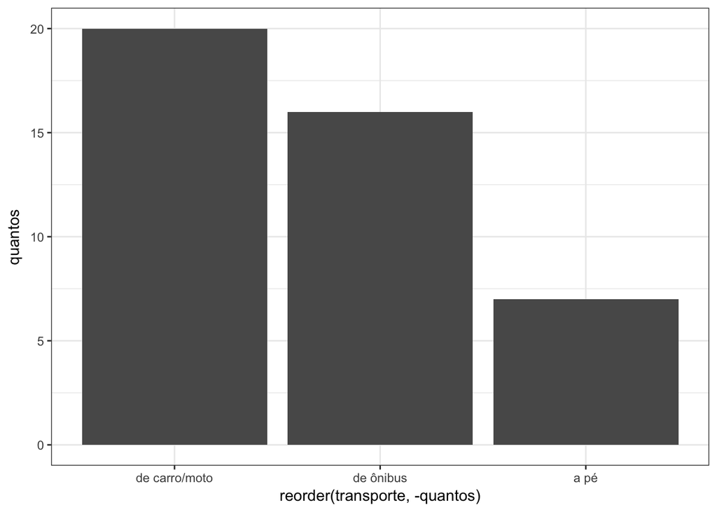

```r
alunos  %>% filter(!is.na(transporte)) %>%
  group_by(transporte) %>%
  summarise(quantos = n()) %>%
  ggplot() +
  geom_col(mapping = aes(x = reorder(transporte, -quantos), y = quantos))
```

## Escala ordinal

O que é? Exemplo?

```r
View(alunos.tudo)
```

Podemos ordenar e obter percentis, moda, top frequent.

```r
summary(as.factor(alunos$gosta_de_forms))
```

```
##  1  2  3  4  5
##  3  4  6 15 16
```

Quem é moda? Quem é top-frequent?

```r
max(table(alunos$gosta_de_forms))/sum(table(alunos$gosta_de_forms))
```

```
## [1] 0.3636364
```

```r
aux <- as.numeric(unlist(alunos %>% select(gosta_de_forms) %>% filter(!is.na(gosta_de_forms))))

alunos %>% select(gosta_de_forms) %>% filter(!is.na(gosta_de_forms)) %>% summarise(mediana = median(gosta_de_forms))
```

```
## # A tibble: 1 x 1
##   mediana
##     <dbl>
## 1       4
```

```r
alunos %>% select(gosta_de_forms) %>% filter(!is.na(gosta_de_forms)) %>% summarise(quartil1 = quantile(gosta_de_forms, 0.25))
```

```
## # A tibble: 1 x 1
##   quartil1
##      <dbl>
## 1        3
```

```r
alunos %>% select(gosta_de_forms) %>% filter(!is.na(gosta_de_forms)) %>% summarise(quartil3 = quantile(gosta_de_forms, 0.75))
```

```
## # A tibble: 1 x 1
##   quartil3
##      <dbl>
## 1        5
```

Podemos ter um histograma de dados ordinais? O que é um histograma?

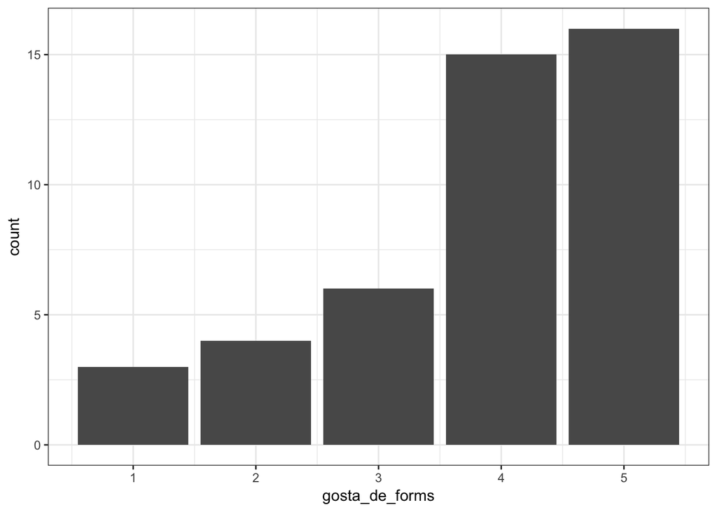

```r
library(ggplot2)

ggplot(alunos %>% filter(!is.na(gosta_de_forms))) +
  geom_bar(mapping = aes(x = gosta_de_forms))
```

## Escalas de razão

São números com suas intensidades e 0 significa ausência do valor medido. Temos exemplos nos dados?

```r
glimpse(alunos)
```

```
## Observations: 44
## Variables: 7
## $ sexo            <chr> "Homem", "Mulher", "Homem", "Homem", "Homem", ...
## $ repositorios    <int> 3, 9, 2, 2, 10, 5, 20, 10, 4, 4, 5, 6, 1, 4, 1...
## $ linguagens      <int> 5, 3, 3, 2, 5, 4, 3, 5, 8, 3, 4, 4, 3, 6, 5, 2...
## $ altura          <int> 0, 154, 0, 181, 186, 182, 184, 167, 182, 160, ...
## $ tempo_para_ufcg <int> 73, 20, 10, 10, 19, 30, 60, 25, 15, 90, 7, 20,...
## $ transporte      <chr> NA, "de carro/moto", "de carro/moto", "a pé", ...
## $ gosta_de_forms  <int> 1, 3, 5, 4, 4, 5, 4, 5, 3, 3, 2, 2, 4, 3, 5, 4...
```

Que variávies tem uma escala de razão? O que podemos fazer com essas variáveis?

Histograma!

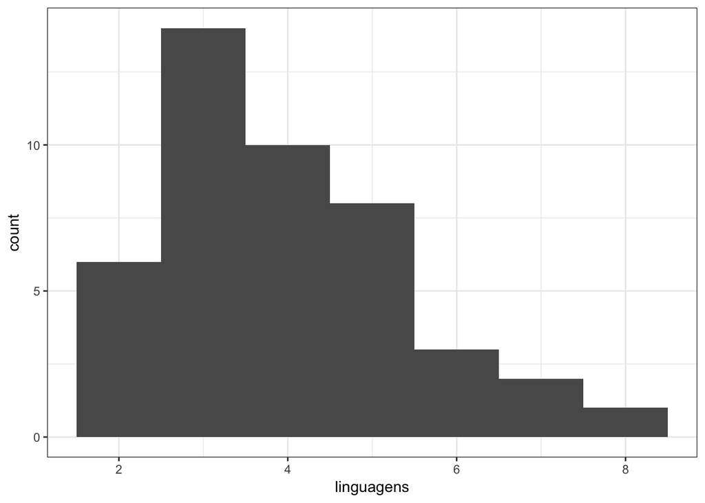

```r
ggplot(alunos, aes(linguagens)) +
  geom_histogram(binwidth = 1)
```

O mesmo podemos fazer para tempo de transporte. Agora considerando por faixas de valores diferentes (Bins = faixas. Binwidth = largura da faixa).

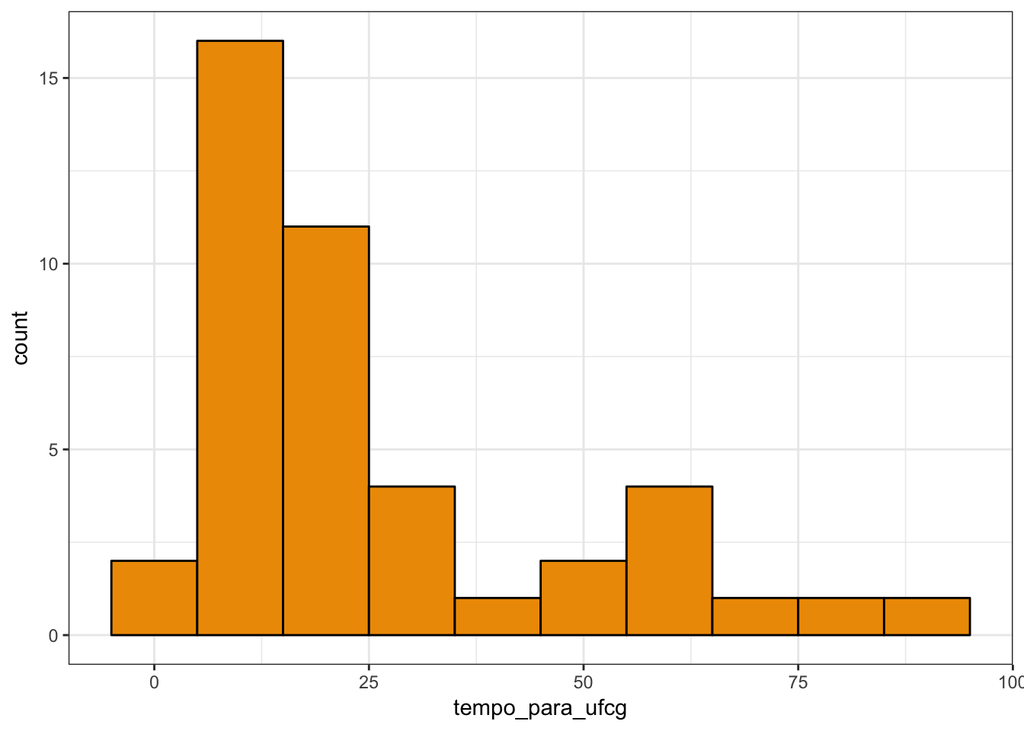

```r
ggplot(alunos, mapping = aes(x = tempo_para_ufcg)) +
  geom_histogram(binwidth = 10,
                 fill = "orange2",
                 colour = "black")
```

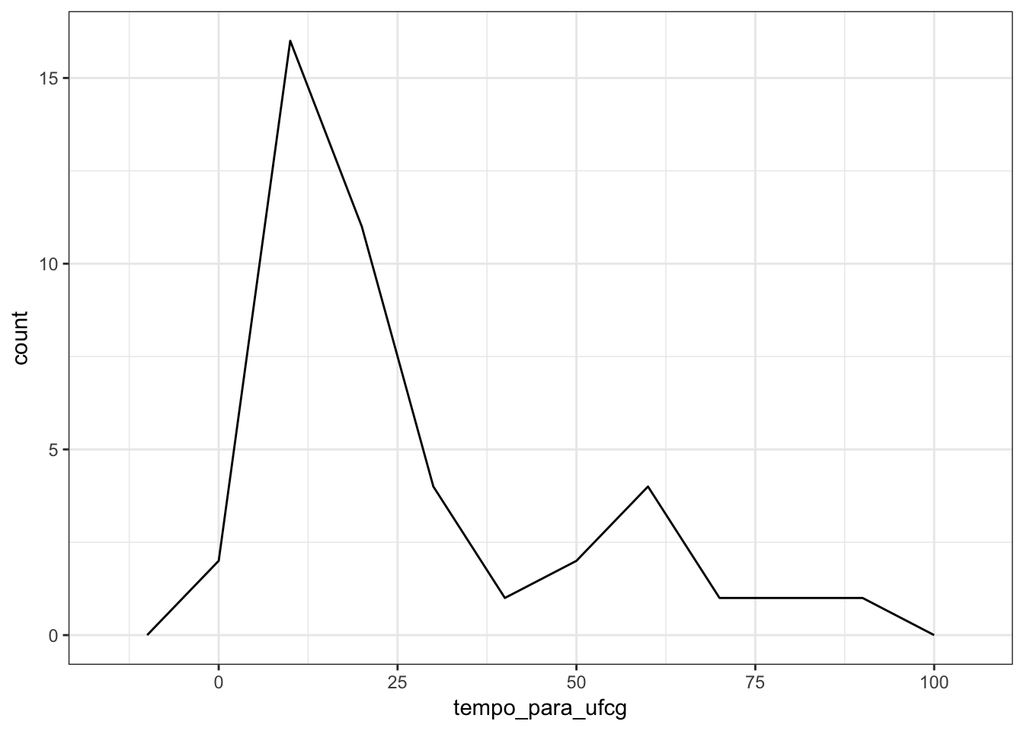

```r
# bins são uma parte muito importante

ggplot(alunos, mapping = aes(x = tempo_para_ufcg)) +
  geom_freqpoly(binwidth = 10,
                 fill = "orange2",
                 colour = "black")
```

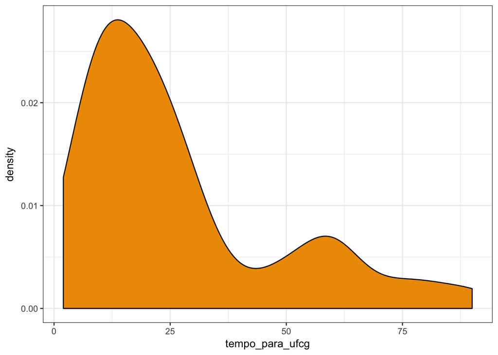

```r
ggplot(alunos, mapping = aes(x = tempo_para_ufcg)) +
  geom_density(fill = "orange2",
                 colour = "black")
```

Para variáveis contínuas, a função de densidade pode ser usada. `geom_freqpoly` também é mais legível quando temos muitos dados.

Mais informação sobre tempo para chegar na UFCG:

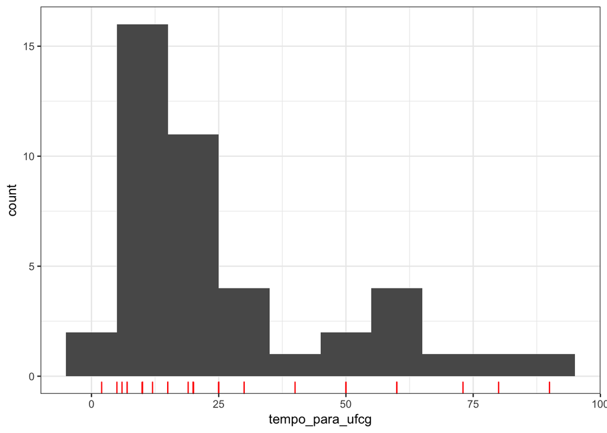

```r
ggplot(alunos, mapping = aes(x = tempo_para_ufcg)) +
  geom_histogram(binwidth = 10) +
  geom_rug(colour = "red")
```

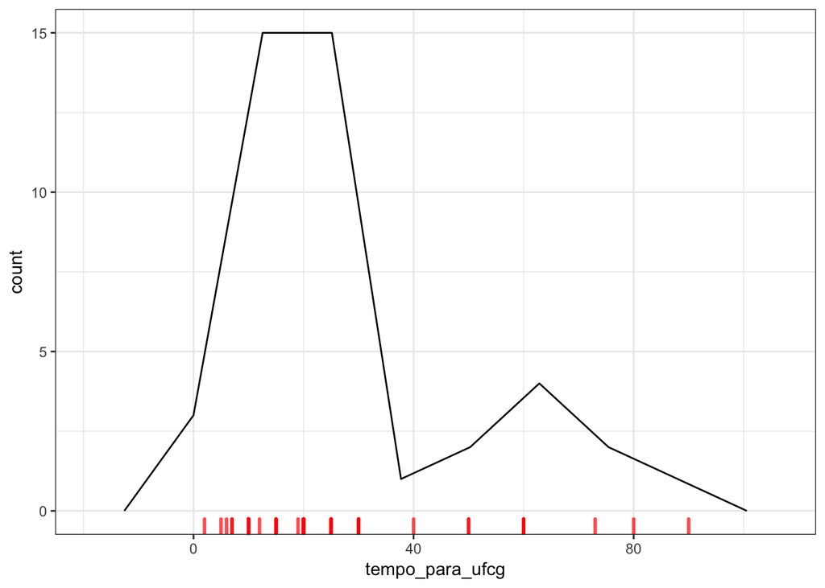

```r
ggplot(alunos, mapping = aes(x = tempo_para_ufcg)) +
  geom_freqpoly(bins = 8) +
  geom_rug(colour = "red", alpha = .7, size = 1)
```

Vamos ver agora a distribuição da altura dos alunos:

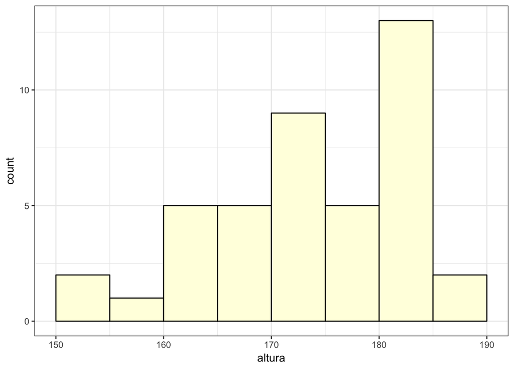

```r
alunos %>%
  filter(altura > 0) %>%
  ggplot() +
  geom_histogram(mapping = aes(x = altura),
                 breaks = seq(150, 190, 5),
                 fill = "lightyellow",
                 color = "black")
```

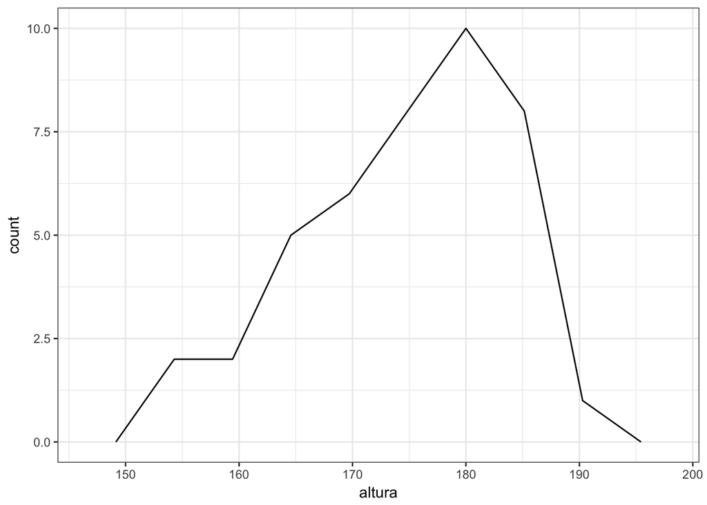

```r
alunos %>%
  filter(altura > 0) %>%
  ggplot() +
  geom_freqpoly(mapping = aes(x = altura),
                bins = 8)
```

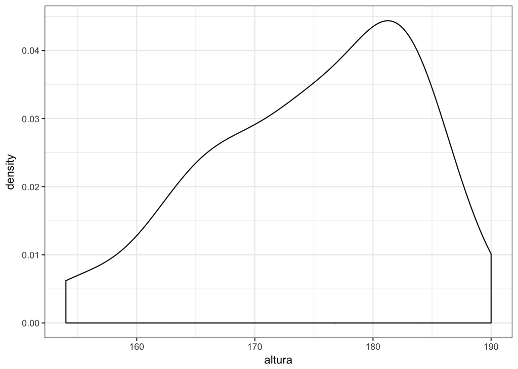

```r
alunos %>%
  filter(altura > 0) %>%
  ggplot() +
  geom_density(mapping = aes(x = altura))
```

## Índices de tendência central e dispersão

```r
mean(as.numeric(unlist(alunos %>% select(linguagens) %>% filter(!is.na(linguagens)))))
```

```
## [1] 3.954545
```

```r
median(as.numeric(unlist(alunos %>% select(linguagens) %>% filter(!is.na(linguagens)))))
```

```
## [1] 4
```

```r
var(as.numeric(unlist(alunos %>% select(linguagens) %>% filter(!is.na(linguagens)))))
```

```
## [1] 2.137421
```

```r
sd(as.numeric(unlist(alunos %>% select(linguagens) %>% filter(!is.na(linguagens)))))
```

```
## [1] 1.461992
```

## Análise exploratória dos dados

Em uma análise exploratória buscamos entender os dados em mãos. Não queremos ainda inferir nada. Como? Fazendo perguntas…

Como as distribuições do “tempo para chegar na UFCG” mudam para cada tipo diferente de transporte?

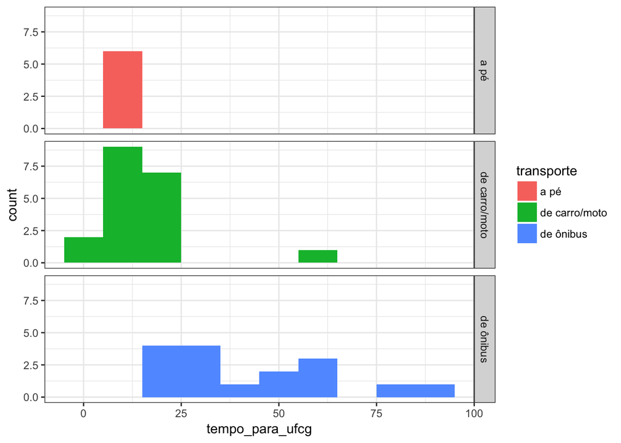

```r
alunos %>%
  filter(complete.cases(.)) %>%
ggplot(aes(fill = transporte, x = tempo_para_ufcg), na.rm = TRUE) +
  geom_histogram(binwidth = 10, na.rm = TRUE) +
  facet_grid(transporte ~ .)
```

### scatter plot

Olhando variáveis de razão e categóricas juntas em um scatterplot:

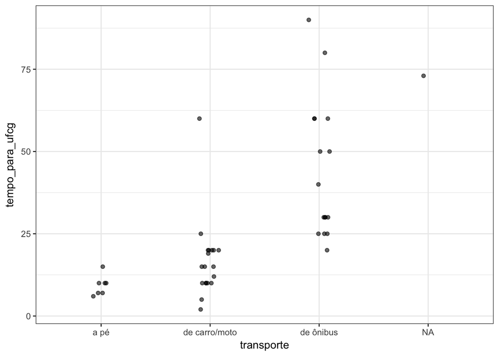

```r
ggplot(alunos, aes(x = transporte, y = tempo_para_ufcg), na.rm=TRUE) +
  geom_jitter(width = .1, height = 0, alpha = .6)
```

### Boxplot

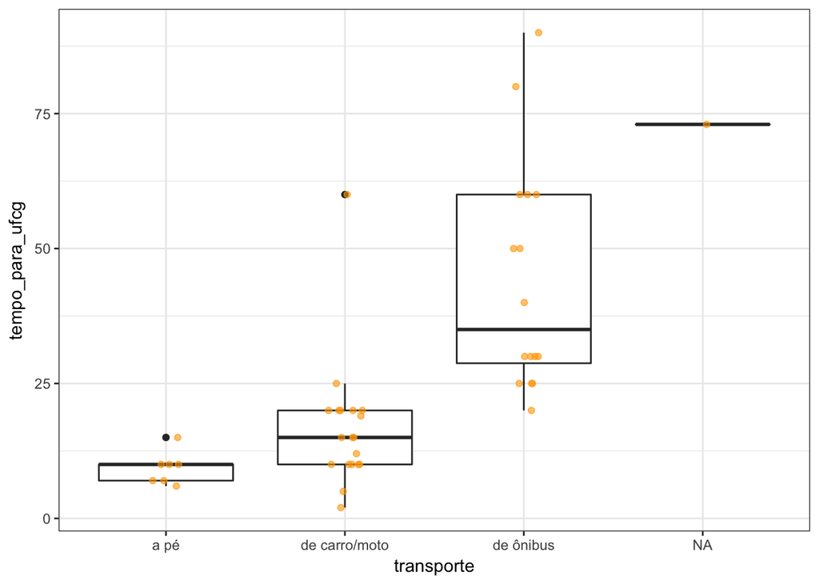

```r
ggplot(alunos, aes(x = transporte, y = tempo_para_ufcg)) +
  geom_boxplot(na.rm=TRUE) +
  geom_jitter(color = "orange", width = .1, height = 0, alpha = .6, na.rm=TRUE)
```

Sem NA:

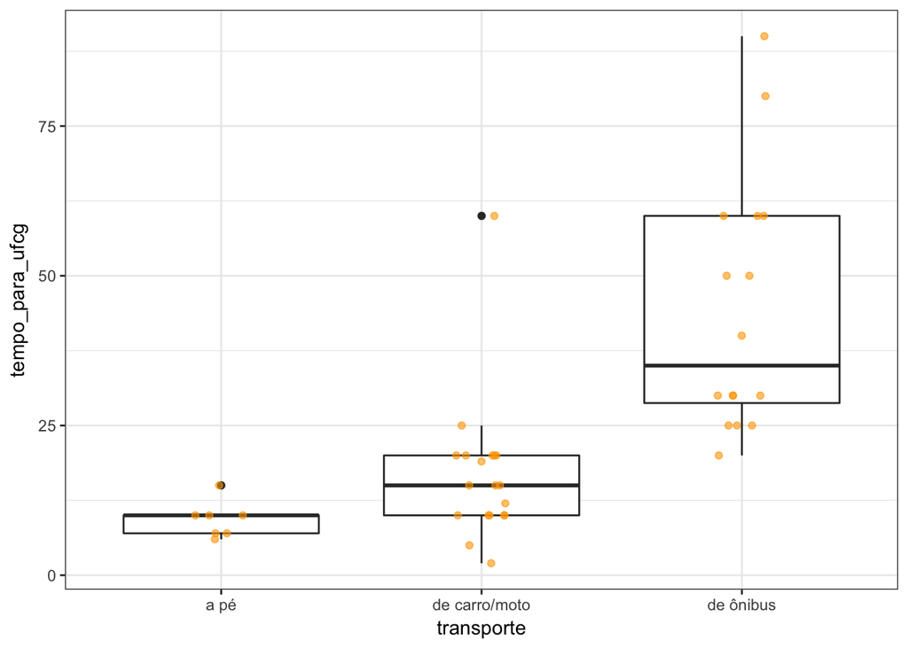

```r
ggplot(subset(alunos, !is.na(transporte)), aes(x = transporte, y = tempo_para_ufcg)) +
  geom_boxplot(na.rm=TRUE) +
  geom_jitter(color = "orange", width = .1, height = 0, alpha = .6, na.rm=TRUE)
```

```r
alunos %>% filter(!is.na(transporte) & !is.na(tempo_para_ufcg)) %>% group_by(transporte) %>% summarise(tempo_minimo = min(tempo_para_ufcg), tempo_de_transporte = mean(tempo_para_ufcg), variabilidade = sd(tempo_para_ufcg), tempo_maximo = max(tempo_para_ufcg))
```

```
## # A tibble: 3 x 5
##   transporte    tempo_minimo tempo_de_transpor… variabilidade tempo_maximo
##   <chr>                <dbl>              <dbl>         <dbl>        <dbl>
## 1 a pé                     6               9.29          3.04           15
## 2 de carro/moto            2              16.7          12.0            60
## 3 de ônibus               20              44.1          21.2            90
```

Será que a altura das pessoas tem relação com seu gênero? homens e mulheres tem a mesma altura?

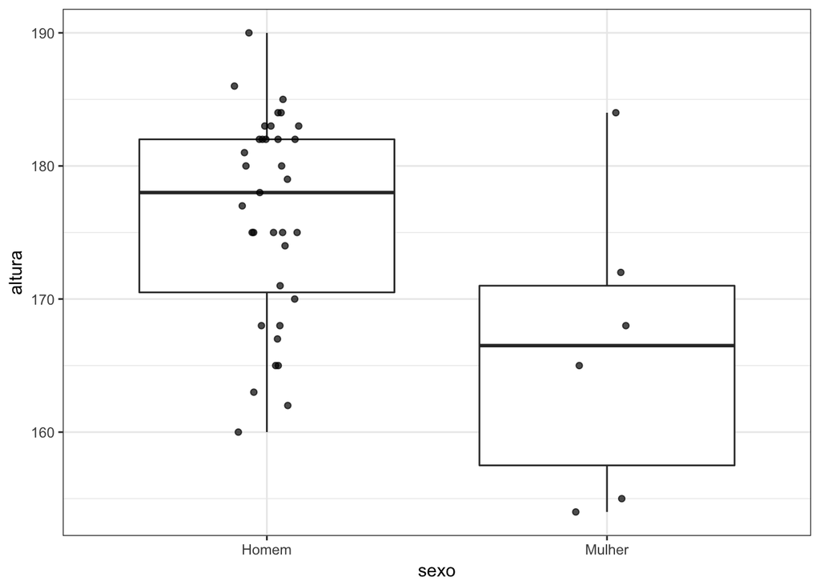

```r
alunos %>%
  filter(altura > 0 & !is.na(altura) & !is.na(sexo)) %>%
  ggplot(mapping = aes(x = sexo,
                       y = altura)) +
   geom_boxplot() +
  #geom_violin() +
  geom_jitter(width = .1,
              height = 0,
              alpha = 0.7)
```

### Scatter plot

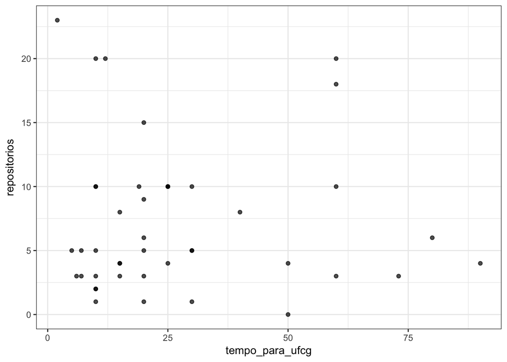

```r
alunos %>%
  ggplot() +
  geom_point(mapping = aes(x = tempo_para_ufcg,
                           y = repositorios),
             alpha = 0.7)
```

Será que os alunos que tem mais repositorios sabem masi linguagens?

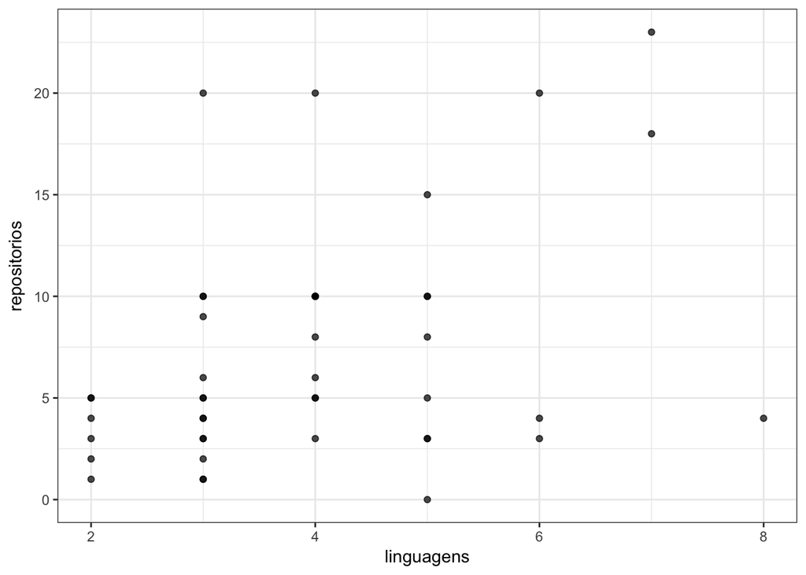

```r
ggplot(data = alunos) +
  geom_point(mapping = aes(x = linguagens,
                           y = repositorios),
             alpha = 0.7)
```

Será que há uma relação entre altura e número de linguagens que um aluno sabe?

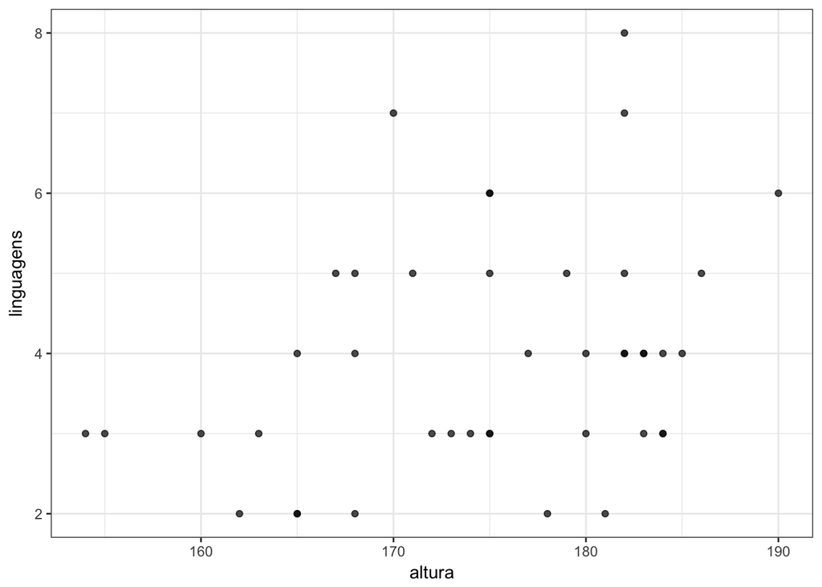

```r
alunos %>%
  filter(altura > 0) %>%
  ggplot() +
  geom_point(mapping = aes(x = altura,
                           y = linguagens),
             alpha = 0.7)
```

Será que os alunos que chegam mais rápido na UFCG tem mais repositórios?

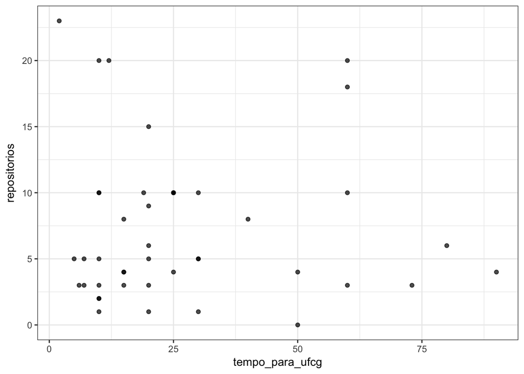

```r
alunos %>%
  ggplot() +
  geom_point(mapping = aes(x = tempo_para_ufcg,
                           y = repositorios),
             alpha = 0.7)
```

### Uma visão geral de todas as variáveis 2 a 2 de uma vez

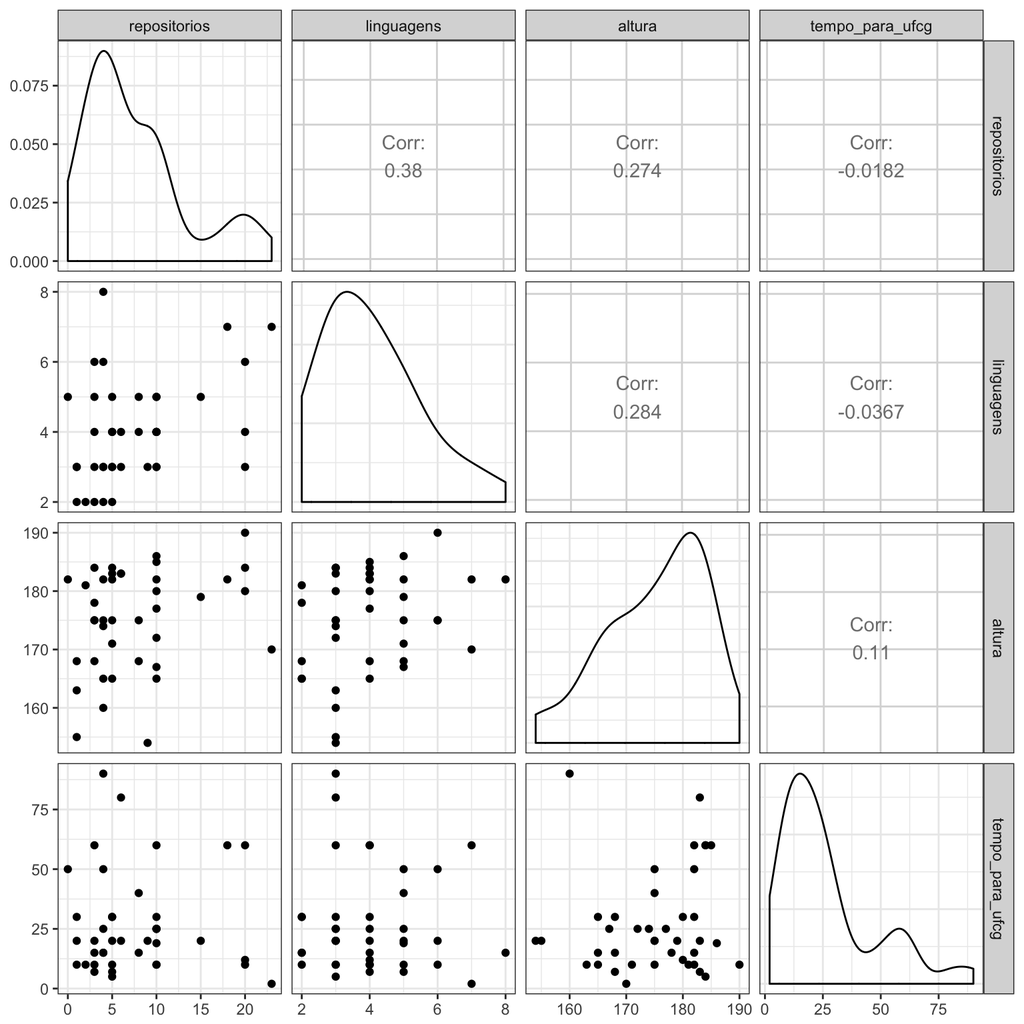

```r
library(GGally)
alunos %>%
  filter(complete.cases(.)) %>%
  filter(altura > 1) %>%
  select(repositorios, linguagens, altura, tempo_para_ufcg) %>%
  ggpairs()
```